# Titanic-Disaster

### 1. Import packages

```python
import os
import numpy as np
import pandas as pd
from tqdm.notebook import tqdm
from copy import deepcopy

import seaborn as sns
import matplotlib.pyplot as plt

from sklearn.metrics import accuracy_score, classification_report
from sklearn.preprocessing import StandardScaler, OneHotEncoder
from sklearn.model_selection import train_test_split

from sklearn.ensemble import RandomForestClassifier
from sklearn.svm import SVC
from xgboost import XGBClassifier

sns.set_style("whitegrid")
```

### 2. Load the data

```python
train = pd.read_csv("../data/train.csv")
train.loc[:, "dataset"] = "train"

valid = pd.read_csv("../data/holdout_test.csv")
valid.loc[:, "dataset"] = "valid"
valid = valid[list(train.columns)]

# Combine them initially to do a overall analysis of the dataset
df = pd.concat([train, valid], ignore_index=True)
df_copy = df.copy()

print(df.shape, train.shape, valid.shape)

df.head()
```

```
(1309, 13) (891, 13) (418, 13)
```

|  | PassengerId | Survived | Pclass | Name | Sex | Age | SibSp | Parch | Ticket | Fare | Cabin | Embarked | dataset |
| --- | --- | --- | --- | --- | --- | --- | --- | --- | --- | --- | --- | --- | --- |
| 0 | 1 | 0.0 | 3 | Braund, Mr. Owen Harris | male | 22.0 | 1 | 0 | A/5 21171 | 7.2500 | NaN | S | train |
| 1 | 2 | 1.0 | 1 | Cumings, Mrs. John Bradley (Florence Briggs Th... | female | 38.0 | 1 | 0 | PC 17599 | 71.2833 | C85 | C | train |
| 2 | 3 | 1.0 | 3 | Heikkinen, Miss. Laina | female | 26.0 | 0 | 0 | STON/O2. 3101282 | 7.9250 | NaN | S | train |
| 3 | 4 | 1.0 | 1 | Futrelle, Mrs. Jacques Heath (Lily May Peel) | female | 35.0 | 1 | 0 | 113803 | 53.1000 | C123 | S | train |
| 4 | 5 | 0.0 | 3 | Allen, Mr. William Henry | male | 35.0 | 0 | 0 | 373450 | 8.0500 | NaN | S | train |

### 3. EDA & Feature Engineering

#### 3.1 PassengerId

```python
# Check NA
print(pd.isna(df.PassengerId).sum()) # No missing values

# Check duplicates
print(len(df.PassengerId.unique()) == len(df)) # No duplicates

# These are just ids are not any adding any feature information. We'll drop them
del df["PassengerId"]
```

```
0
True
```

#### 3.2 Pclass

```python
pd.isna(df.Pclass).sum()
```

```
0
```

```python
df.Pclass.value_counts()
```

```
3    709
1    323
2    277
Name: Pclass, dtype: int64
```

```python
# Check if there's a relation with survival status
np.round(pd.crosstab(df.Pclass, df.Survived, normalize="index") * 100, 2)
```

| Survived Pclass | 0.0 | 1.0 |
| --- | --- | --- |
| 1 | 37.04 | 62.96 |
| 2 | 52.72 | 47.28 |
| 3 | 75.76 | 24.24 |

**63% passengers from first class cabins survived while only 24% did from the third class. This is a good descriptor to keep. Let's visualize this data using a count plot.**

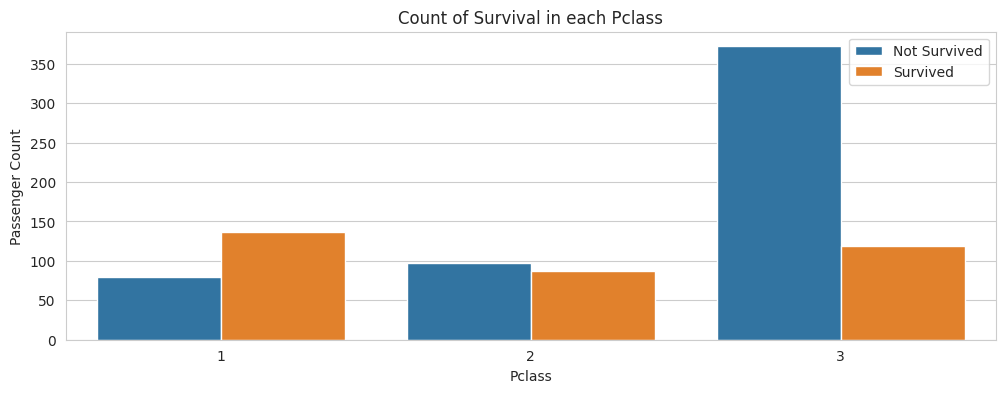

```python
fig, axs = plt.subplots(figsize=(12, 4))

sns.countplot(x='Pclass', hue='Survived', data=df[df.dataset == "train"])

plt.xlabel('Pclass')
plt.ylabel('Passenger Count')

plt.legend(['Not Survived', 'Survived'], loc='upper right')
plt.title('Count of Survival in each Pclass')

plt.show()
```

```python
# This is a categorical variable. We'll OneHotEncode them

pclass = pd.get_dummies(df.Pclass, prefix="Pclass", prefix_sep="_")
del df["Pclass"]

pclass.head()
```

|  | Pclass_1 | Pclass_2 | Pclass_3 |
| --- | --- | --- | --- |
| 0 | 0 | 0 | 1 |
| 1 | 1 | 0 | 0 |
| 2 | 0 | 0 | 1 |
| 3 | 1 | 0 | 0 |
| 4 | 0 | 0 | 1 |

#### 3.3 Sex

```python
pd.isna(df.Sex).sum()
```

```
0
```

```python
df.Sex.value_counts()
```

```
male      843
female    466
Name: Sex, dtype: int64
```

```python
# Check if there's a relation with survival status
np.round(pd.crosstab(df.Sex, df.Survived, normalize="index") * 100, 2)
```

| Survived Sex | 0.0 | 1.0 |
| --- | --- | --- |
| female | 25.80 | 74.20 |
| male | 81.11 | 18.89 |

**74% females survived but only 19% males did. Again a good descriptor to have. Below count plot helps visualize this point.**

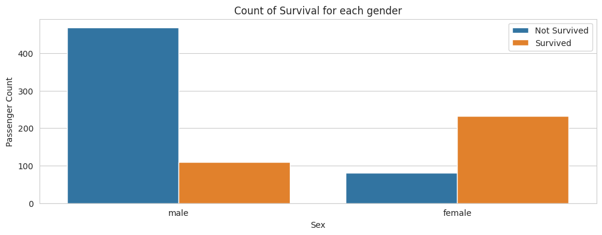

```python
fig, axs = plt.subplots(figsize=(12, 4))

sns.countplot(x='Sex', hue='Survived', data=df[df.dataset == "train"])

plt.xlabel('Sex')
plt.ylabel('Passenger Count')

plt.legend(['Not Survived', 'Survived'], loc='upper right')
plt.title('Count of Survival for each gender')

plt.show()
```

```python
# Gender is a binary so we'll replace it with 0 and 1

sex = df[["Sex"]].copy()
sex["Sex"] = sex["Sex"].map({"male": 0, "female": 1})
del df["Sex"]

sex.head()
```

|  | Sex |
| --- | --- |
| 0 | 0 |
| 1 | 1 |
| 2 | 1 |
| 3 | 1 |
| 4 | 0 |

#### 3.4 SibSp - Number of siblings/spouses aboard the Titanic

```python
pd.isna(df.SibSp).sum()
```

```
0
```

```python
df.SibSp.value_counts()
```

```
0    891
1    319
2     42
4     22
3     20
8      9
5      6
Name: SibSp, dtype: int64
```

```python
# Check if there's a relation with survival status
np.round(pd.crosstab(df.SibSp, df.Survived, normalize="index") * 100, 2)
```

| Survived SibSp | 0.0 | 1.0 |
| --- | --- | --- |
| 0 | 65.46 | 34.54 |
| 1 | 46.41 | 53.59 |
| 2 | 53.57 | 46.43 |
| 3 | 75.00 | 25.00 |
| 4 | 83.33 | 16.67 |
| 5 | 100.00 | 0.00 |
| 8 | 100.00 | 0.00 |

**As number of dependents increase, survival rate deceases, with the exception of people who had no dependents. They have a lesser chance of surviving than with 1 or 2 dependents. We'll treat this as a continuous variable since there's a order among the categories.**

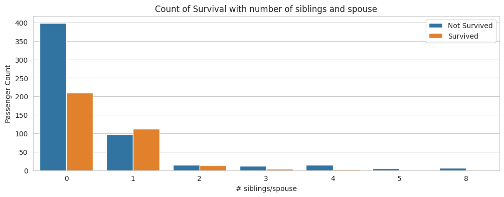

```python
fig, axs = plt.subplots(figsize=(12, 4))

sns.countplot(x='SibSp', hue='Survived', data=df[df.dataset == "train"])

plt.xlabel('# siblings/spouse')
plt.ylabel('Passenger Count')

plt.legend(['Not Survived', 'Survived'], loc='upper right')
plt.title('Count of Survival with number of siblings and spouse')

plt.show()
```

```python
sibsp = df[["SibSp"]].copy()
del df["SibSp"]

sibsp.head()
```

|  | SibSp |
| --- | --- |
| 0 | 1 |
| 1 | 1 |
| 2 | 0 |
| 3 | 1 |
| 4 | 0 |

#### 3.5 Parch - Number of parents/children aboard the Titanic

```python
pd.isna(df.Parch).sum()
```

```
0
```

```python
df.Parch.value_counts()
```

```
0    1002
1     170
2     113
3       8
5       6
4       6
6       2
9       2
Name: Parch, dtype: int64
```

```python
# Check if there's a relation with survival status
np.round(pd.crosstab(df.Parch, df.Survived, normalize="index") * 100, 2)
```

| Survived Parch | 0.0 | 1.0 |
| --- | --- | --- |
| 0 | 65.63 | 34.37 |
| 1 | 44.92 | 55.08 |
| 2 | 50.00 | 50.00 |
| 3 | 40.00 | 60.00 |
| 4 | 100.00 | 0.00 |
| 5 | 80.00 | 20.00 |
| 6 | 100.00 | 0.00 |

**Some `Parch` categories have a high survival rate than the others. We'll take this as a continuous variable as well.**

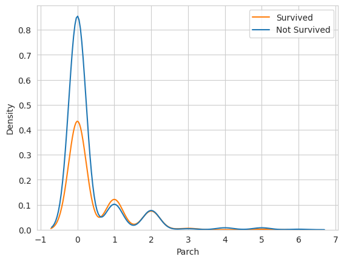

```python
sns.kdeplot(data=df[df.dataset == "train"], x="Parch", hue="Survived")

plt.legend(['Survived', 'Not Survived'], loc='upper right')

plt.show()
```

**A huge spike in the distribution of the people who did or didn't survive when passengers had no parents and children.**

```python
parch = df[["Parch"]].copy()
del df["Parch"]

parch.head()
```

|  | Parch |
| --- | --- |
| 0 | 0 |
| 1 | 0 |
| 2 | 0 |
| 3 | 0 |
| 4 | 0 |

#### 3.6 Embarked - Port of Embarkation

```python
pd.isna(df.Embarked).sum()  # Two missing values
```

```
2
```

```python
# Show the two passengers

df_copy[pd.isna(df_copy.Embarked)]
```

|  | PassengerId | Survived | Pclass | Name | Sex | Age | SibSp | Parch | Ticket | Fare | Cabin | Embarked | dataset |
| --- | --- | --- | --- | --- | --- | --- | --- | --- | --- | --- | --- | --- | --- |
| 61 | 62 | 1.0 | 1 | Icard, Miss. Amelie | female | 38.0 | 0 | 0 | 113572 | 80.0 | B28 | NaN | train |
| 829 | 830 | 1.0 | 1 | Stone, Mrs. George Nelson (Martha Evelyn) | female | 62.0 | 0 | 0 | 113572 | 80.0 | B28 | NaN | train |

**Both are from first class and the same cabin `B28`. Let's see which port other first class passengers boarded from.**

```python
pd.crosstab(df_copy.Embarked, df_copy.Pclass)
```

| Pclass Embarked | 1 | 2 | 3 |
| --- | --- | --- | --- |
| C | 141 | 28 | 101 |
| Q | 3 | 7 | 113 |
| S | 177 | 242 | 495 |

**Most of them either boarder from `C` or `S` port. Let's see the boarding port for all the cabins in the range `B20 - B29`. It's possible that nearby cabins are filled from the same port.**

```python
df_copy[df_copy.Cabin.str.contains("B2", na=False)].Embarked.value_counts()
```

```
S    6
Name: Embarked, dtype: int64
```

**All of them embarked from `S` port. We'll assign `S` to the two missing values.**

```python
df["Embarked"] = df.Embarked.fillna('S')
df["Embarked"] = df.Embarked.apply(lambda x: "Port_" + x)
```

```python
# Check if there's a relation with survival status
np.round(pd.crosstab(df.Embarked, df.Survived, normalize="index") * 100, 2)
```

| Survived Embarked | 0.0 | 1.0 |
| --- | --- | --- |
| Port_C | 44.64 | 55.36 |
| Port_Q | 61.04 | 38.96 |
| Port_S | 66.10 | 33.90 |

**People boarded from `Q` and `S` have lesser chances of survival. This is a categorical variable.**

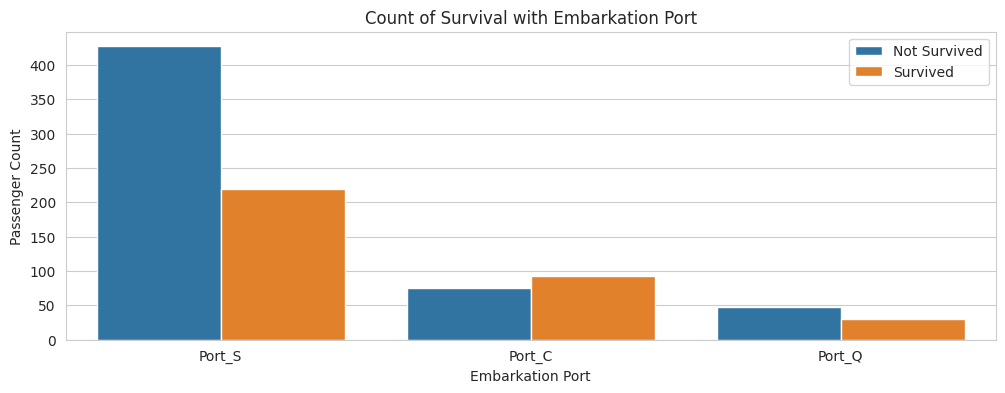

```python
fig, axs = plt.subplots(figsize=(12, 4))

sns.countplot(x='Embarked', hue='Survived', data=df[df.dataset == "train"])

plt.xlabel('Embarkation Port')
plt.ylabel('Passenger Count')

plt.legend(['Not Survived', 'Survived'], loc='upper right')
plt.title('Count of Survival with Embarkation Port')

plt.show()
```

```python
embarked = pd.get_dummies(df.Embarked)
del df["Embarked"]

embarked.head()
```

|  | Port_C | Port_Q | Port_S |
| --- | --- | --- | --- |
| 0 | 0 | 0 | 1 |
| 1 | 1 | 0 | 0 |
| 2 | 0 | 0 | 1 |
| 3 | 0 | 0 | 1 |
| 4 | 0 | 0 | 1 |

#### 3.7 Cabin - Cabin number

```python
pd.isna(df.Cabin).sum()
```

```
1014
```

**Most of the cabin numbers are missing. However, cabin numbers can provide us an idea about the passenger location in the ship which can help in decide whether they survived. We'll extract the cabin letters and divide them into different categories. Missing values are added to a `other` class.**

```python
df["CabinLetter"] = df.Cabin.apply(lambda x: "Cabin_" + str(x)[0])

df.CabinLetter.value_counts()
```

```
Cabin_n    1014
Cabin_C      94
Cabin_B      65
Cabin_D      46
Cabin_E      41
Cabin_A      22
Cabin_F      21
Cabin_G       5
Cabin_T       1
Name: CabinLetter, dtype: int64
```

**Here `Cabin_n` represents missing cabin numbers. There is only one passenger in `Cabin_T`. We will mark it as `Cabin_n`.**

```python
df.loc[df.CabinLetter == "Cabin_T", "CabinLetter"] = "Cabin_n"

# Check if there's a relation with survival status
np.round(pd.crosstab(df.CabinLetter, df.Survived, normalize="index") * 100, 2)
```

| Survived CabinLetter | 0.0 | 1.0 |
| --- | --- | --- |
| Cabin_A | 53.33 | 46.67 |
| Cabin_B | 25.53 | 74.47 |
| Cabin_C | 40.68 | 59.32 |
| Cabin_D | 24.24 | 75.76 |
| Cabin_E | 25.00 | 75.00 |
| Cabin_F | 38.46 | 61.54 |
| Cabin_G | 50.00 | 50.00 |
| Cabin_n | 70.06 | 29.94 |

**Clearly passengers from certain cabins like `B`, `D`, and `E` have much higher chances of survival than others. 70% of passengers with missing cabin numbers didn't survive. This is a categorical variable.**

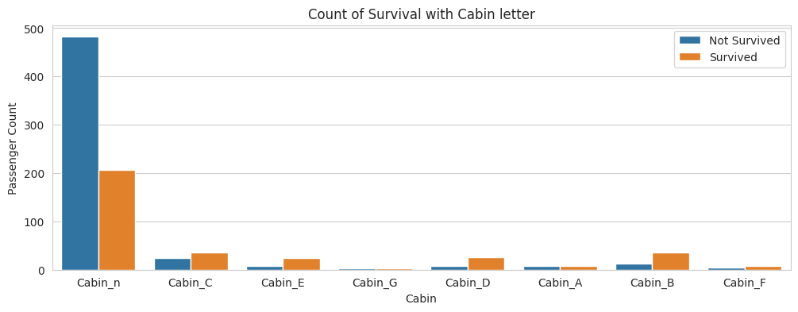

```python
fig, axs = plt.subplots(figsize=(12, 4))

sns.countplot(x='CabinLetter', hue='Survived', data=df[df.dataset == "train"])

plt.xlabel('Cabin')
plt.ylabel('Passenger Count')

plt.legend(['Not Survived', 'Survived'], loc='upper right')
plt.title('Count of Survival with Cabin letter')

plt.show()
```

```python
cabin = pd.get_dummies(df.CabinLetter)
del df["CabinLetter"], df["Cabin"]

cabin.head()
```

|  | Cabin_A | Cabin_B | Cabin_C | Cabin_D | Cabin_E | Cabin_F | Cabin_G | Cabin_n |
| --- | --- | --- | --- | --- | --- | --- | --- | --- |
| 0 | 0 | 0 | 0 | 0 | 0 | 0 | 0 | 1 |
| 1 | 0 | 0 | 1 | 0 | 0 | 0 | 0 | 0 |
| 2 | 0 | 0 | 0 | 0 | 0 | 0 | 0 | 1 |
| 3 | 0 | 0 | 1 | 0 | 0 | 0 | 0 | 0 |
| 4 | 0 | 0 | 0 | 0 | 0 | 0 | 0 | 1 |

#### 3.8 Fare - Passenger fare

```python
pd.isna(df.Fare).sum()
```

```
1
```

**There's one passenger with missing fare. Let's show them.**

```python
df_copy[pd.isna(df_copy.Fare)]
```

|  | PassengerId | Survived | Pclass | Name | Sex | Age | SibSp | Parch | Ticket | Fare | Cabin | Embarked | dataset |
| --- | --- | --- | --- | --- | --- | --- | --- | --- | --- | --- | --- | --- | --- |
| 1043 | 1044 | NaN | 3 | Storey, Mr. Thomas | male | 60.5 | 0 | 0 | 3701 | NaN | NaN | S | valid |

**This passenger is from 3rd class and embarked from the `S` port. We can take median of fares of similar passengers.**

```python
fare_median = df_copy[(df_copy.Pclass == 3) & (df_copy.Embarked == "S")].Fare.median()
fare_median
```

```
8.05
```

```python
df.loc[pd.isna(df.Fare), "Fare"] = fare_median
```

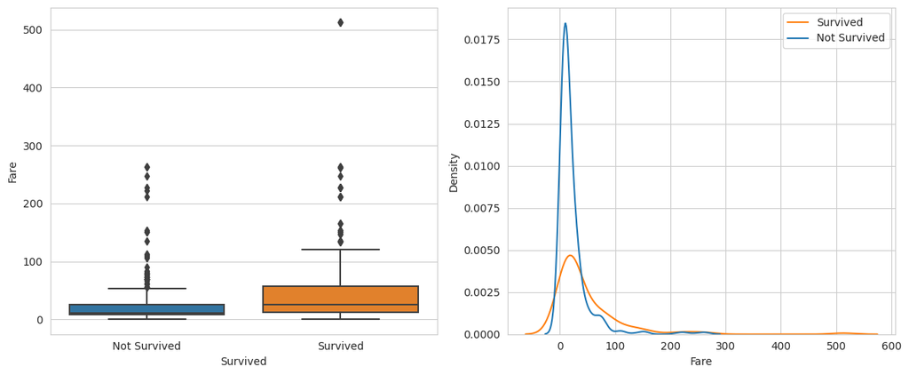

```python
fig, axes = plt.subplots(1, 2, figsize=(12, 5))

sns.boxplot(data=df[df.dataset == "train"], y="Fare", x="Survived", ax=axes[0])
sns.kdeplot(data=df[df.dataset == "train"], x="Fare", hue="Survived", ax=axes[1])

axes[0].set_xticklabels(labels=['Not Survived', 'Survived'])
axes[1].legend(['Survived', 'Not Survived'], loc='upper right')

plt.tight_layout()
plt.show()
```

**Passengers who survived tend to have a higher fare. Further, there's big spike in survivality status of passengers when the fare is around 10 units. There are also quite a few outliers in the fare. We can divide the fare into different bins (ranges).**

```python
df['FareBins'] = pd.qcut(df['Fare'], q=10)  # We'll divide it into 10 quantiles
```

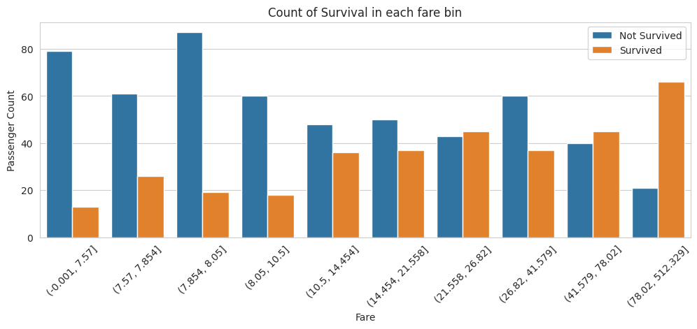

```python
fig, axs = plt.subplots(figsize=(12, 4))

sns.countplot(x='FareBins', hue='Survived', data=df[df.dataset == "train"])

plt.xlabel('Fare')
plt.ylabel('Passenger Count')

plt.legend(['Not Survived', 'Survived'], loc='upper right')
plt.title('Count of Survival in each fare bin')

plt.xticks(rotation=45)

plt.show()
```

**As fare increases, survival rate increases, generally.**

```python
fare = pd.get_dummies(df.FareBins)
fare.columns = ["FareBin_" + str(c).strip("(]").replace(", ", "-") for c in fare.columns]

del df["Fare"], df["FareBins"]

fare.head()
```

|  | FareBin_-0.001-7.57 | FareBin_7.57-7.854 | FareBin_7.854-8.05 | FareBin_8.05-10.5 | FareBin_10.5-14.454 | FareBin_14.454-21.558 | FareBin_21.558-26.82 | FareBin_26.82-41.579 | FareBin_41.579-78.02 | FareBin_78.02-512.329 |
| --- | --- | --- | --- | --- | --- | --- | --- | --- | --- | --- |
| 0 | 1 | 0 | 0 | 0 | 0 | 0 | 0 | 0 | 0 | 0 |
| 1 | 0 | 0 | 0 | 0 | 0 | 0 | 0 | 0 | 1 | 0 |
| 2 | 0 | 0 | 1 | 0 | 0 | 0 | 0 | 0 | 0 | 0 |
| 3 | 0 | 0 | 0 | 0 | 0 | 0 | 0 | 0 | 1 | 0 |
| 4 | 0 | 0 | 1 | 0 | 0 | 0 | 0 | 0 | 0 | 0 |

#### 3.9 Age - Age in years

```python
pd.isna(df.Age).sum()
```

```
263
```

**Quite a few missing values. We can fill them with median ages but not a good idea to take median of whole dataset. We can use the passenger names to infer if they are children, adult or older people. For example, if a name contains `Master` or `Miss`, they are likely to be younger in age. Similarly, if the name contains `Mr`, `Mrs`, or `Dr.`, they are likely older in age.**

```python
df.Name.head()  # Second word, immediately after a comma, seems to be the title
```

```
0                              Braund, Mr. Owen Harris
1    Cumings, Mrs. John Bradley (Florence Briggs Th...
2                               Heikkinen, Miss. Laina
3         Futrelle, Mrs. Jacques Heath (Lily May Peel)
4                             Allen, Mr. William Henry
Name: Name, dtype: object
```

```python
df["title"] = df.Name.apply(lambda x: x.split(",")[1].split()[0])
df.title.head()
```

```
0      Mr.
1     Mrs.
2    Miss.
3     Mrs.
4      Mr.
Name: title, dtype: object
```

```python
df[pd.isna(df.Age)].title.value_counts()
```

```
Mr.        176
Miss.       50
Mrs.        27
Master.      8
Dr.          1
Ms.          1
Name: title, dtype: int64
```

**Everything looks good. Now we can replace the age with the median of corresponding titles.**

```python
median_age = dict(df.groupby("title").Age.median())
median_age
```

```
{'Capt.': 70.0,
 'Col.': 54.5,
 'Don.': 40.0,
 'Dona.': 39.0,
 'Dr.': 49.0,
 'Jonkheer.': 38.0,
 'Lady.': 48.0,
 'Major.': 48.5,
 'Master.': 4.0,
 'Miss.': 22.0,
 'Mlle.': 24.0,
 'Mme.': 24.0,
 'Mr.': 29.0,
 'Mrs.': 35.5,
 'Ms.': 28.0,
 'Rev.': 41.5,
 'Sir.': 49.0,
 'the': 33.0}
```

```python
df.loc[pd.isna(df.Age), "Age"] = df[pd.isna(df.Age)].title.apply(lambda x: median_age[x])
```

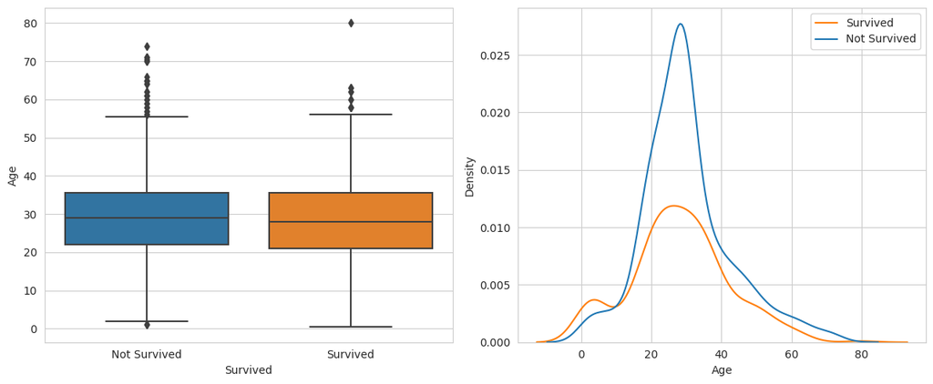

```python
fig, axes = plt.subplots(1, 2, figsize=(12, 5))

sns.boxplot(data=df[df.dataset == "train"], y="Age", x="Survived", ax=axes[0])
sns.kdeplot(data=df[df.dataset == "train"], x="Age", hue="Survived", ax=axes[1])

axes[0].set_xticklabels(labels=['Not Survived', 'Survived'])
axes[1].legend(['Survived', 'Not Survived'], loc='upper right')

plt.tight_layout()
plt.show()
```

**From the boxplot, we see that the distribution is quite similar for both passengers who did and didn't survive. But the density plot shows a spike for passengers of age around 25. We can divide the age between bins to leverage this feature.**

```python
df['AgeBins'] = pd.qcut(df['Age'], q=5)  # We'll divide it into 10 quantiles
```

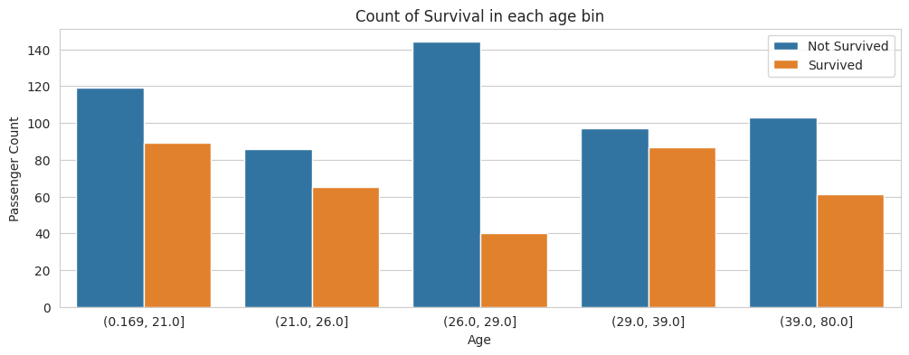

```python
fig, axs = plt.subplots(figsize=(12, 4))

sns.countplot(x='AgeBins', hue='Survived', data=df[df.dataset == "train"])

plt.xlabel('Age')
plt.ylabel('Passenger Count')

plt.legend(['Not Survived', 'Survived'], loc='upper right')
plt.title('Count of Survival in each age bin')

# plt.xticks(rotation=45)

plt.show()
```

**For different bins, the survival count is varying. For example, for passengers between the age of 26 and 29, an unusually high number of them didn't survive.**

```python
age = pd.get_dummies(df.AgeBins)
age.columns = ["AgeBin_" + str(c).strip("(]").replace(", ", "-") for c in age.columns]

del df["Age"], df["AgeBins"], df["title"], df["Name"]

age.head()
```

|  | AgeBin_0.169-21.0 | AgeBin_21.0-26.0 | AgeBin_26.0-29.0 | AgeBin_29.0-39.0 | AgeBin_39.0-80.0 |
| --- | --- | --- | --- | --- | --- |
| 0 | 0 | 1 | 0 | 0 | 0 |
| 1 | 0 | 0 | 0 | 1 | 0 |
| 2 | 0 | 1 | 0 | 0 | 0 |
| 3 | 0 | 0 | 0 | 1 | 0 |
| 4 | 0 | 0 | 0 | 1 | 0 |

#### 3.10 Ticket - Ticket number

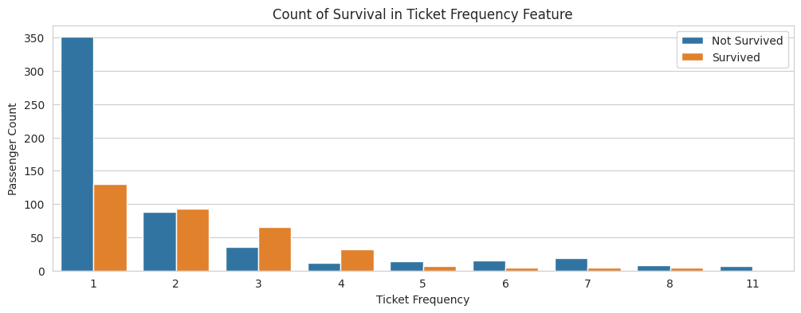

```python
df['TicketFrequency'] = df.groupby('Ticket')['Ticket'].transform('count')

fig, axs = plt.subplots(figsize=(12, 4))
sns.countplot(x='TicketFrequency', hue='Survived', data=df)

plt.xlabel('Ticket Frequency')
plt.ylabel('Passenger Count')

plt.legend(['Not Survived', 'Survived'], loc='upper right')
plt.title('Count of Survival in Ticket Frequency Feature')

plt.show()
```

**Ticket can indicate the family size (a family is likely to have the same ticket numbers) but that information is already available from the `SibSp` and `Parch` variables. So we can just drop this column.**

```python
del df["Ticket"], df["TicketFrequency"]
```

#### 3.11 Survived

```python
pd.isna(df[df.dataset == "train"].Survived).sum()  # No mising values
```

```
0
```

```python
np.round(df.Survived.value_counts(normalize=True), 2)
```

```
0.0    0.62
1.0    0.38
Name: Survived, dtype: float64
```

**There's class imbalance in the target variable as Class 1 has only 38% of the data points. Model is likely to have comparatively lower precision and recall for this class.**

### 4. Modeling

**Now, the data analysis and feature engineering is done, we'll combine all the variables and start the modeling process.**

```python
processed_df = pd.concat([df, pclass, sex, sibsp, parch, embarked, cabin, fare, age], axis=1)
print(processed_df.shape)

processed_df.head()
```

```
(1309, 34)
```

|  | Survived | dataset | Pclass_1 | Pclass_2 | Pclass_3 | Sex | SibSp | Parch | Port_C | Port_Q | ... | FareBin_14.454-21.558 | FareBin_21.558-26.82 | FareBin_26.82-41.579 | FareBin_41.579-78.02 | FareBin_78.02-512.329 | AgeBin_0.169-21.0 | AgeBin_21.0-26.0 | AgeBin_26.0-29.0 | AgeBin_29.0-39.0 | AgeBin_39.0-80.0 |
| --- | --- | --- | --- | --- | --- | --- | --- | --- | --- | --- | --- | --- | --- | --- | --- | --- | --- | --- | --- | --- | --- |
| 0 | 0.0 | train | 0 | 0 | 1 | 0 | 1 | 0 | 0 | 0 | ... | 0 | 0 | 0 | 0 | 0 | 0 | 1 | 0 | 0 | 0 |
| 1 | 1.0 | train | 1 | 0 | 0 | 1 | 1 | 0 | 1 | 0 | ... | 0 | 0 | 0 | 1 | 0 | 0 | 0 | 0 | 1 | 0 |
| 2 | 1.0 | train | 0 | 0 | 1 | 1 | 0 | 0 | 0 | 0 | ... | 0 | 0 | 0 | 0 | 0 | 0 | 1 | 0 | 0 | 0 |
| 3 | 1.0 | train | 1 | 0 | 0 | 1 | 1 | 0 | 0 | 0 | ... | 0 | 0 | 0 | 1 | 0 | 0 | 0 | 0 | 1 | 0 |
| 4 | 0.0 | train | 0 | 0 | 1 | 0 | 0 | 0 | 0 | 0 | ... | 0 | 0 | 0 | 0 | 0 | 0 | 0 | 0 | 1 | 0 |

5 rows × 34 columns

```python
train = processed_df[processed_df.dataset == "train"].copy()
y = train.Survived.values
del train["Survived"], train["dataset"]

X_train, X_test, y_train, y_test = train_test_split(train, y, test_size=0.2, stratify=y, random_state=5)

X_valid = processed_df[processed_df.dataset == "valid"].copy()
del X_valid["Survived"], X_valid["dataset"]

print(X_train.shape, X_test.shape, X_valid.shape)
```

```
(712, 32) (179, 32) (418, 32)
```

**Check for any unusual correlation between the features.**

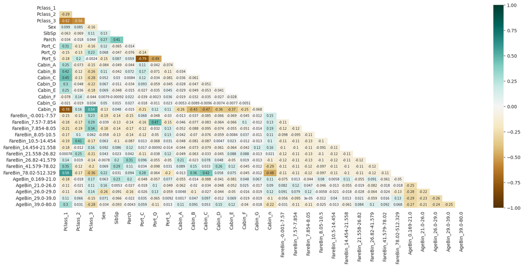

```python
plt.figure(figsize=(20, 8))

mask = np.triu(np.ones_like(X_train.corr(), dtype=np.bool_))
sns.heatmap(X_train.corr(), cmap='BrBG', mask=mask, annot=True, annot_kws={"fontsize": 7},
            vmin=-1, vmax=1)

plt.show()
```

**There are noticeable correlations but none of them are high enough to be worried. Let's standardize the dataset next.**

```python
scaler = StandardScaler()
features = X_train.columns

X_train = scaler.fit_transform(X_train)
X_train = pd.DataFrame(data=X_train, columns=features)

X_test = scaler.transform(X_test)
X_test = pd.DataFrame(data=X_test, columns=features)

X_valid = scaler.transform(X_valid)
X_valid = pd.DataFrame(data=X_valid, columns=features)
```

**Build a RandomForest, SVM and XGBoost classifier models.**

```python
rf = RandomForestClassifier(n_estimators=20, max_depth=5, random_state=42)
rf.fit(X_train, y_train)

train_pred = rf.predict(X_train)
test_pred = rf.predict(X_test)

print(f"Training accuracy: {round(accuracy_score(y_train, train_pred)*100, 1)}%")
print(f"Testing accuracy : {round(accuracy_score(y_test, test_pred)*100, 1)}%")

print()
print(classification_report(y_test, test_pred))
```

```
Training accuracy: 83.4%
Testing accuracy : 83.8%

              precision    recall  f1-score   support

         0.0       0.81      0.95      0.88       110
         1.0       0.90      0.65      0.76        69

    accuracy                           0.84       179
   macro avg       0.86      0.80      0.82       179
weighted avg       0.85      0.84      0.83       179
```

```python
svm = SVC(random_state=42)
svm.fit(X_train, y_train)

train_pred = svm.predict(X_train)
test_pred = svm.predict(X_test)

print(f"Training accuracy: {round(accuracy_score(y_train, train_pred)*100, 1)}%")
print(f"Testing accuracy : {round(accuracy_score(y_test, test_pred)*100, 1)}%")

print()
print(classification_report(y_test, test_pred))
```

```
Training accuracy: 86.2%
Testing accuracy : 81.0%

              precision    recall  f1-score   support

         0.0       0.81      0.90      0.85       110
         1.0       0.81      0.67      0.73        69

    accuracy                           0.81       179
   macro avg       0.81      0.78      0.79       179
weighted avg       0.81      0.81      0.81       179
```

```python
xgb = XGBClassifier(n_estimators=50, max_depth=5, random_state=42)
xgb.fit(X_train, y_train)

train_pred = xgb.predict(X_train)
test_pred = xgb.predict(X_test)

print(f"Training accuracy: {round(accuracy_score(y_train, train_pred)*100, 1)}%")
print(f"Testing accuracy : {round(accuracy_score(y_test, test_pred)*100, 1)}%")

print()
print(classification_report(y_test, test_pred))
```

```
Training accuracy: 89.5%
Testing accuracy : 82.7%

              precision    recall  f1-score   support

         0.0       0.81      0.94      0.87       110
         1.0       0.87      0.65      0.74        69

    accuracy                           0.83       179
   macro avg       0.84      0.79      0.81       179
weighted avg       0.83      0.83      0.82       179
```

**Above results are obtained after a trying lots of combination of hyperparameters. SVM and XGBoost sometimes gave a slightly higher accuracy than RandomForest but both these models also tended to overfit. RandomForest found a balance between train and test accuracy for above combination. We'll take the RandomForest as the final model. Only thing that's left now is making prediction on the holdout dataset.**

### 5. Prediction on holdout dataset

```python
valid_preds = rf.predict(X_valid)
results = valid.copy()
results["Survived"] = valid_preds

results["Survived"] = results.Survived.astype(int)

results.head()
```

[output not shown]

```python
results.to_csv("../data/Titanic-Results-from-Manish-Kumar.csv", index=False)
```

```python
feat_imp_data = np.array([features, rf.feature_importances_]).transpose()
feat_imp = pd.DataFrame(data=feat_imp_data, columns=["Features", "Importance Scores"])
feat_imp = feat_imp.sort_values(by="Importance Scores", ascending=False)
feat_imp.head()
```

|  | Features | Importance Scores |
| --- | --- | --- |
| 3 | Sex | 0.402789 |
| 2 | Pclass_3 | 0.135352 |
| 16 | Cabin_n | 0.081916 |
| 4 | SibSp | 0.033 |
| 0 | Pclass_1 | 0.030774 |

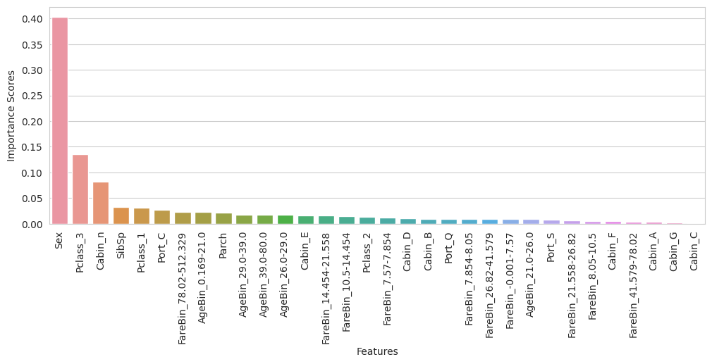

```python
plt.figure(figsize=(12, 4))
sns.barplot(data=feat_imp, x="Features", y="Importance Scores")

plt.xticks(rotation=90)
plt.show()
```

**As per the selected `RandomForest` model, the gender of passengers, missing cabin number, and the passanger class are among the top indicators in deciding whether a passenger will survive or not.**